# PMarquardt_HW9_7.12.2018

Paul Marquardt

July 11, 2018

### Question 1B: . Scrape the page with any R package that makes things easy for you. Of particular

interest is the table of the Cast in order of crediting. Please scrape this table (you might have to fish it out of several of the tables from the page) and make it a data.frame() of the Cast in your R environment

```r
# Input the website to be scraped in to the URL variable
url <- 'https://www.imdb.com/title/tt1201607/fullcredits?ref_=tt_ql_1'

# Read the raw webpage into the webpage.raw variable
webpage.raw <- read_html(url)
```

### Question 1C: Clean up the table

. It should not have blank observations or rows, a row that should be column names, or just ‘.’

```r
# Use CSS selectors to scrape the actor and character names
cast.name.html <- webpage.raw %>%
  html_nodes(xpath = '//*[@class="cast_list"]//span[@itemprop="name"]')

#head(cast.name.html)
cast.character.html <- html_nodes(webpage.raw,'.character')
#head(cast.character.html)

# Converting the cast data to text
cast.name <- html_text(cast.name.html)
cast.character <- html_text(cast.character.html)

#Let's have a look at the data!
head(cast.name)
```

```
## [1] "Ralph Fiennes"    "Michael Gambon"   "Alan Rickman"
## [4] "Daniel Radcliffe" "Rupert Grint"     "Emma Watson"
```

```r
head(cast.character)
```

```
## [1] "\n            Lord Voldemort \n                  \n          "
## [2] "\n            Professor Albus Dumbledore \n                  \n          "
## [3] "\n            Professor Severus Snape \n                  \n          "
## [4] "\n            Harry Potter \n                  \n          "
## [5] "\n            Ron Weasley \n                  \n          "
## [6] "\n            Hermione Granger \n                  \n          "
```

```r
cast.name
```

```
##   [1] "Ralph Fiennes"                 "Michael Gambon"
##   [3] "Alan Rickman"                  "Daniel Radcliffe"
##   [5] "Rupert Grint"                  "Emma Watson"
##   [7] "Evanna Lynch"                  "Domhnall Gleeson"
##   [9] "Clémence Poésy"                "Warwick Davis"
##  [11] "John Hurt"                     "Helena Bonham Carter"
##  [13] "Graham Duff"                   "Anthony Allgood"
##  [15] "Rusty Goffe"                   "Jon Key"
##  [17] "Kelly Macdonald"               "Jason Isaacs"
##  [19] "Helen McCrory"                 "Tom Felton"
##  [21] "Ian Peck"                      "Benn Northover"
##  [23] "Ciarán Hinds"                  "Hebe Beardsall"
##  [25] "Matthew Lewis"                 "Devon Murray"
##  [27] "Jessie Cave"                   "Afshan Azad"
##  [29] "Isabella Laughland"            "Anna Shaffer"
```

[output cut: 60 more lines]

```r
cast.character
```

```
##   [1] "\n            Lord Voldemort \n                  \n          "
##   [2] "\n            Professor Albus Dumbledore \n                  \n          "
##   [3] "\n            Professor Severus Snape \n                  \n          "
##   [4] "\n            Harry Potter \n                  \n          "
##   [5] "\n            Ron Weasley \n                  \n          "
##   [6] "\n            Hermione Granger \n                  \n          "
##   [7] "\n            Luna Lovegood \n                  \n          "
##   [8] "\n            Bill Weasley \n                  \n          "
##   [9] "\n            Fleur Delacour \n                  \n          "
##  [10] "\n            Griphook /  \n            Professor Filius Flitwick \n                  \n          "
##  [11] "\n            Ollivander \n                  \n          "
##  [12] "\n            Bellatrix Lestrange \n                  \n          "
##  [13] "\n            Death Eater \n                  \n          "
##  [14] "\n            Gringotts' Guard \n                  \n          "
##  [15] "\n            Aged Gringotts' Goblin \n                  \n          "
```

[output cut: 134 more lines]

```r
# Check out length to see if they match
length(cast.name)
```

```
## [1] 149
```

```r
length(cast.character)
```

```
## [1] 149
```

```r
# Clean up unwanted whitespace and characters in our text
cast.character <-gsub("\n","",cast.character)
head(cast.character)
```

```
## [1] "            Lord Voldemort                             "
## [2] "            Professor Albus Dumbledore                             "
## [3] "            Professor Severus Snape                             "
## [4] "            Harry Potter                             "
## [5] "            Ron Weasley                             "
## [6] "            Hermione Granger                             "
```

```r
trimws(cast.character, which = ("both"))
```

```
##   [1] "Lord Voldemort"
##   [2] "Professor Albus Dumbledore"
##   [3] "Professor Severus Snape"
##   [4] "Harry Potter"
##   [5] "Ron Weasley"
##   [6] "Hermione Granger"
##   [7] "Luna Lovegood"
##   [8] "Bill Weasley"
##   [9] "Fleur Delacour"
##  [10] "Griphook /              Professor Filius Flitwick"
##  [11] "Ollivander"
##  [12] "Bellatrix Lestrange"
##  [13] "Death Eater"
##  [14] "Gringotts' Guard"
##  [15] "Aged Gringotts' Goblin"
```

[output cut: 134 more lines]

```r
head(cast.character)
```

```
## [1] "            Lord Voldemort                             "
## [2] "            Professor Albus Dumbledore                             "
## [3] "            Professor Severus Snape                             "
## [4] "            Harry Potter                             "
## [5] "            Ron Weasley                             "
## [6] "            Hermione Granger                             "
```

```r
trimws(cast.name, which = ("both"))
```

```
##   [1] "Ralph Fiennes"                 "Michael Gambon"
##   [3] "Alan Rickman"                  "Daniel Radcliffe"
##   [5] "Rupert Grint"                  "Emma Watson"
##   [7] "Evanna Lynch"                  "Domhnall Gleeson"
##   [9] "Clémence Poésy"                "Warwick Davis"
##  [11] "John Hurt"                     "Helena Bonham Carter"
##  [13] "Graham Duff"                   "Anthony Allgood"
##  [15] "Rusty Goffe"                   "Jon Key"
##  [17] "Kelly Macdonald"               "Jason Isaacs"
##  [19] "Helen McCrory"                 "Tom Felton"
##  [21] "Ian Peck"                      "Benn Northover"
##  [23] "Ciarán Hinds"                  "Hebe Beardsall"
##  [25] "Matthew Lewis"                 "Devon Murray"
##  [27] "Jessie Cave"                   "Afshan Azad"
##  [29] "Isabella Laughland"            "Anna Shaffer"
```

[output cut: 60 more lines]

```r
head(cast.name)
```

```
## [1] "Ralph Fiennes"    "Michael Gambon"   "Alan Rickman"
## [4] "Daniel Radcliffe" "Rupert Grint"     "Emma Watson"
```

```r
# Convert out text data into a data frame
movie.cast <- data.frame(cast.name, cast.character)
head(movie.cast)
```

```
##          cast.name
## 1    Ralph Fiennes
## 2   Michael Gambon
## 3     Alan Rickman
## 4 Daniel Radcliffe
## 5     Rupert Grint
## 6      Emma Watson
##                                                        cast.character
## 1                         Lord Voldemort
## 2             Professor Albus Dumbledore
## 3                Professor Severus Snape
## 4                           Harry Potter
## 5                            Ron Weasley
## 6                       Hermione Granger
```

### Question 1C2: . It should have intuitive column names (ideally 2 to start - Actor and

Character)

```r
# Assign names to our columns
names(movie.cast) <- c('Actor','Character')
head(movie.cast)
```

```
##              Actor
## 1    Ralph Fiennes
## 2   Michael Gambon
## 3     Alan Rickman
## 4 Daniel Radcliffe
## 5     Rupert Grint
## 6      Emma Watson
##                                                             Character
## 1                         Lord Voldemort
## 2             Professor Albus Dumbledore
## 3                Professor Severus Snape
## 4                           Harry Potter
## 5                            Ron Weasley
## 6                       Hermione Granger
```

### Find out character anomoly 1C:3: . In the film, Mr. Warwick plays two characters, which makes his row look a

little weird. Please replace his character column with just “Griphook / Professor Filius Flitwick” to make it look better. . One row might result in “Rest of cast listed alphabetically” - remove this observation.

```r
grep("Warwick",movie.cast$Actor)
```

```
## [1] 10
```

```r
head(movie.cast, 10)
```

```
##               Actor
## 1     Ralph Fiennes
## 2    Michael Gambon
## 3      Alan Rickman
## 4  Daniel Radcliffe
## 5      Rupert Grint
## 6       Emma Watson
## 7      Evanna Lynch
## 8  Domhnall Gleeson
## 9    Clémence Poésy
## 10    Warwick Davis
##                                                                                     Character
## 1                                                 Lord Voldemort
## 2                                     Professor Albus Dumbledore
## 3                                        Professor Severus Snape
## 4                                                   Harry Potter
## 5                                                    Ron Weasley
## 6                                               Hermione Granger
## 7                                                  Luna Lovegood
## 8                                                   Bill Weasley
## 9                                                 Fleur Delacour
## 10             Griphook /              Professor Filius Flitwick
```

```r
movie.cast$Character <- gsub("Griphook /              Professor Filius Flitwick", "Griphook/Professor Filius Flitwick", movie.cast$Character)
head(movie.cast, 10)
```

```
##               Actor
## 1     Ralph Fiennes
## 2    Michael Gambon
## 3      Alan Rickman
## 4  Daniel Radcliffe
## 5      Rupert Grint
## 6       Emma Watson
## 7      Evanna Lynch
## 8  Domhnall Gleeson
## 9    Clémence Poésy
## 10    Warwick Davis
##                                                                      Character
## 1                                  Lord Voldemort
## 2                      Professor Albus Dumbledore
## 3                         Professor Severus Snape
## 4                                    Harry Potter
## 5                                     Ron Weasley
## 6                                Hermione Granger
## 7                                   Luna Lovegood
## 8                                    Bill Weasley
## 9                                  Fleur Delacour
## 10             Griphook/Professor Filius Flitwick
```

### Question 1D: Split the Actor’s name into two columns: FirstName and Surname. Keep in mind that

some actors/actresses have middle names as well. Please make sure that the middle names are in the FirstName column, in addition to the first name (example: given the Actor Frank Jeffrey Stevenson, the FirstName column would say “Frank Jeffrey.”) e. Present the first 10 rows of the data.frame() - It should have only FirstName, Surname, and Character columns.

```r
# Separate Names and create new data frame with corrected formatting
last.name <- last_name(movie.cast$Actor)
first.name <- first_name(movie.cast$Actor)
full.cast <- data.frame(first.name, last.name, cast.character)
head(full.cast)
```

```
##   first.name last.name
## 1      Ralph   Fiennes
## 2    Michael    Gambon
## 3       Alan   Rickman
## 4     Daniel Radcliffe
## 5     Rupert     Grint
## 6       Emma    Watson
##                                                        cast.character
## 1                         Lord Voldemort
## 2             Professor Albus Dumbledore
## 3                Professor Severus Snape
## 4                           Harry Potter
## 5                            Ron Weasley
## 6                       Hermione Granger
```

```r
names(full.cast) <- c('First', 'Last', 'Character')
full.cast$Character <- gsub("Griphook /              Professor Filius Flitwick", "Griphook/Professor Filius Flitwick", movie.cast$Character)
```

### Question 1E: Present the first 10 rows of the data.frame() - It should have only FirstName, Surname,

and Character columns.

```r
head(full.cast,10)
```

```
##        First      Last
## 1      Ralph   Fiennes
## 2    Michael    Gambon
## 3       Alan   Rickman
## 4     Daniel Radcliffe
## 5     Rupert     Grint
## 6       Emma    Watson
## 7     Evanna     Lynch
## 8   Domhnall   Gleeson
## 9  ClÃ©mence    PoÃ©sy
## 10   Warwick     Davis
##                                                                      Character
## 1                                  Lord Voldemort
## 2                      Professor Albus Dumbledore
## 3                         Professor Severus Snape
## 4                                    Harry Potter
## 5                                     Ron Weasley
## 6                                Hermione Granger
## 7                                   Luna Lovegood
## 8                                    Bill Weasley
## 9                                  Fleur Delacour
## 10             Griphook/Professor Filius Flitwick
```

### Question 2a: On the ESPN website, there are statistics of each NBA player. Navigate to the San

Antonio Spurs current statistics (likely http://www.espn.com/nba/team/stats/_/name/sa/san-antonio-spurs). You are interested in the Shooting Statistics table.

```r
library(RCurl)
# Grab ESPN Spurs raw site into the url varibale
spurs.url <- "http://www.espn.com/nba/team/stats/_/name/sa/san-antonio-spurs"
```

### Question 2b: Scrape the page with any R package that makes things easy for you. There are a few

tables on the page, so make sure you are targeting specifically the Shooting Statistics table.

```r
# Read HTML from ESPN
spurs.raw <- read_html("http://www.espn.com/nba/team/stats/_/name/sa/san-antonio-spurs")
spurs.raw <- htmlParse(spurs.raw)

# Find Second Table xpath tablehead
table2 <- "(//table[@class='tablehead'])[2]/tr[contains(@class, 'oddrow player')]/td | (//table[@class='tablehead'])[2]/tr[contains(@class, 'evenrow player')]/td"
results <- xpathSApply(spurs.raw, table2, xmlValue)
stats <- data.frame( matrix(results, nrow=14, ncol =15, byrow = TRUE), stringsAsFactors=FALSE )

# Grab the column names
table2 <- "(//table[@class='tablehead'])[2]/tr[@class='colhead']/td"
results <- xpathSApply(spurs.raw, table2, xmlValue)

# Assign the names to our matrix
names(stats) <- make.names(results)

# Grab out column names
col.head <- "(//table[@class='tablehead'])[2]/tr[@class='colhead']/td"
results <- xpathSApply(spurs.raw, col.head, xmlValue)
names(stats) <- make.names(results)
#head(stats)
```

### Question 2c: Clean up the table (You might get some warnings if you’re working with tibbles)

```r
# Remove unwanted \n character from name column
stats$PLAYER <- gsub("\n","",stats$PLAYER)
head(stats)
```

```
##                  PLAYER FGM  FGA  FG. X3PM X3PA X3P. FTM FTA  FT. X2PM
## 1 LaMarcus Aldridge, PF 7.4 16.0 .463  0.6  1.0 .600 8.2 8.4 0.98  6.8
## 2       Patty Mills, PG 5.0 11.4 .439  2.6  7.0 .371 0.8 1.0 0.80  2.4
## 3          Rudy Gay, SF 5.2 13.0 .400  0.8  3.6 .222 1.0 1.8 0.56  4.4
## 4     Manu Ginobili, SG 3.0  7.4 .405  1.2  3.6 .333 1.8 2.2 0.82  1.8
## 5   Dejounte Murray, PG 2.8  6.2 .452  0.8  1.2 .667 1.4 1.8 0.78  2.0
## 6       Tony Parker, PG 2.8  7.4 .378  0.0  1.0 .000 1.0 1.4 0.71  2.8
##   X2PA X2P.   PPS AFG.
## 1 15.0 .453 1.475 0.48
## 2  4.4 .545 1.175 0.55
## 3  9.4 .468  .938 0.43
## 4  3.8 .474 1.216 0.49
## 5  5.0 .400 1.258 0.52
## 6  6.4 .438  .892 0.38
```

### Question 2c.1:

. You’ll want to create an R data.frame() with one observation for each player. Make sure that you do not accidentally include blank rows, a row of column names, or the Totals row in the table as observations.

```r
stats
```

```
##                   PLAYER FGM  FGA   FG. X3PM X3PA X3P. FTM FTA  FT. X2PM
## 1  LaMarcus Aldridge, PF 7.4 16.0  .463  0.6  1.0 .600 8.2 8.4 0.98  6.8
## 2        Patty Mills, PG 5.0 11.4  .439  2.6  7.0 .371 0.8 1.0 0.80  2.4
## 3           Rudy Gay, SF 5.2 13.0  .400  0.8  3.6 .222 1.0 1.8 0.56  4.4
## 4      Manu Ginobili, SG 3.0  7.4  .405  1.2  3.6 .333 1.8 2.2 0.82  1.8
## 5    Dejounte Murray, PG 2.8  6.2  .452  0.8  1.2 .667 1.4 1.8 0.78  2.0
## 6        Tony Parker, PG 2.8  7.4  .378  0.0  1.0 .000 1.0 1.4 0.71  2.8
## 7           Pau Gasol, C 2.0  4.0  .500  0.2  0.6 .333 1.8 2.0 0.90  1.8
## 8      Kyle Anderson, SF 2.4  4.0  .600  0.0  0.8 .000 0.6 0.8 0.75  2.4
## 9        Bryn Forbes, SG 1.3  4.3  .294  0.5  2.3 .222 1.3 1.8 0.71  0.8
## 10       Danny Green, SG 1.6  6.0  .267  1.0  4.0 .250 0.0 0.0 0.00  0.6
## 11      Davis Bertans, C 0.6  3.6  .167  0.6  3.2 .188 1.6 2.2 0.73  0.0
## 12     Derrick White, PG 1.0  2.0  .500  0.3  0.7 .500 0.0 0.0 0.00  0.7
## 13  Joffrey Lauvergne, C 1.0  1.0 1.000  0.0  0.0 .000 0.0 0.0 0.00  1.0
## 14      Brandon Paul, SG 0.0  0.0  .000  0.0  0.0 .000 0.0 0.0 0.00  0.0
##    X2PA  X2P.   PPS AFG.
## 1  15.0  .453 1.475 0.48
## 2   4.4  .545 1.175 0.55
## 3   9.4  .468  .938 0.43
## 4   3.8  .474 1.216 0.49
## 5   5.0  .400 1.258 0.52
## 6   6.4  .438  .892 0.38
## 7   3.4  .529 1.500 0.53
## 8   3.2  .750 1.350 0.60
## 9   2.0  .375 1.000 0.35
## 10  2.0  .300  .700 0.35
## 11  0.4  .000  .944 0.25
## 12  1.3  .500 1.167 0.58
## 13  1.0 1.000 2.000 1.00
## 14  0.0  .000  .000 0.00
```

### Question 2c.2:

. The column PLAYER has two variables of interest in it: the player’s name and their position, denoted by 1-2 letters after their name. Split the cells into two columns, one with Name and the other Position.

```r
# Create a vector for first and last names
split.player <- data.frame(do.call( 'rbind', strsplit( as.character(stats$PLAYER),", ",fixed=TRUE)))
names(split.player) <- c('Player', 'Position')
stats$PLAYER <- split.player$Player
stats$Position <- split.player$Position
stats$PLAYER <- gsub("\n","",stats$PLAYER)
stats
```

```
##               PLAYER FGM  FGA   FG. X3PM X3PA X3P. FTM FTA  FT. X2PM X2PA
## 1  LaMarcus Aldridge 7.4 16.0  .463  0.6  1.0 .600 8.2 8.4 0.98  6.8 15.0
## 2        Patty Mills 5.0 11.4  .439  2.6  7.0 .371 0.8 1.0 0.80  2.4  4.4
## 3           Rudy Gay 5.2 13.0  .400  0.8  3.6 .222 1.0 1.8 0.56  4.4  9.4
## 4      Manu Ginobili 3.0  7.4  .405  1.2  3.6 .333 1.8 2.2 0.82  1.8  3.8
## 5    Dejounte Murray 2.8  6.2  .452  0.8  1.2 .667 1.4 1.8 0.78  2.0  5.0
## 6        Tony Parker 2.8  7.4  .378  0.0  1.0 .000 1.0 1.4 0.71  2.8  6.4
## 7          Pau Gasol 2.0  4.0  .500  0.2  0.6 .333 1.8 2.0 0.90  1.8  3.4
## 8      Kyle Anderson 2.4  4.0  .600  0.0  0.8 .000 0.6 0.8 0.75  2.4  3.2
## 9        Bryn Forbes 1.3  4.3  .294  0.5  2.3 .222 1.3 1.8 0.71  0.8  2.0
## 10       Danny Green 1.6  6.0  .267  1.0  4.0 .250 0.0 0.0 0.00  0.6  2.0
## 11     Davis Bertans 0.6  3.6  .167  0.6  3.2 .188 1.6 2.2 0.73  0.0  0.4
## 12     Derrick White 1.0  2.0  .500  0.3  0.7 .500 0.0 0.0 0.00  0.7  1.3
## 13 Joffrey Lauvergne 1.0  1.0 1.000  0.0  0.0 .000 0.0 0.0 0.00  1.0  1.0
## 14      Brandon Paul 0.0  0.0  .000  0.0  0.0 .000 0.0 0.0 0.00  0.0  0.0
##     X2P.   PPS AFG. Position
## 1   .453 1.475 0.48       PF
## 2   .545 1.175 0.55       PG
## 3   .468  .938 0.43       SF
## 4   .474 1.216 0.49       SG
## 5   .400 1.258 0.52       PG
## 6   .438  .892 0.38       PG
## 7   .529 1.500 0.53        C
## 8   .750 1.350 0.60       SF
## 9   .375 1.000 0.35       SG
## 10  .300  .700 0.35       SG
## 11  .000  .944 0.25        C
## 12  .500 1.167 0.58       PG
## 13 1.000 2.000 1.00        C
## 14  .000  .000 0.00       SG
```

### Question 2c.3:

. Check the data type of all columns. Convert relevant columns to numeric. Check the data type of all columns again to confirm that they have changed!

```r
# Convert stats field to numeric
stats <- transform( stats, FGM = as.numeric(FGM), FGA = as.numeric(FGA), FG. = as.numeric(FG.), X3PM = as.numeric(X3PM), X3PA = as.numeric(X3PA), X3P. = as.numeric(X3P.), FTM = as.numeric(FTM), FTA = as.numeric(FTA), FT. = as.numeric(FT.), X2PM = as.numeric(X2PM),X2PA = as.numeric(X2PA),X2P. = as.numeric(X2P.),PPS = as.numeric(PPS), AFG. = as.numeric(AFG.))
```

### Question 2d:. Create a colorful bar chart that shows the Field Goals Percentage Per Game for each

person. It will be graded on the following criteria. . Informative Title, centered . Relevant x and y axis labels (not simply variables names!) . Human-readable axes with no overlap (you might have to flip x and y to fix that). Note: You do not have to convert the decimal to a percentage. . Color the columns by the team member’s position (so, all PF’s should have the same color, etc.)

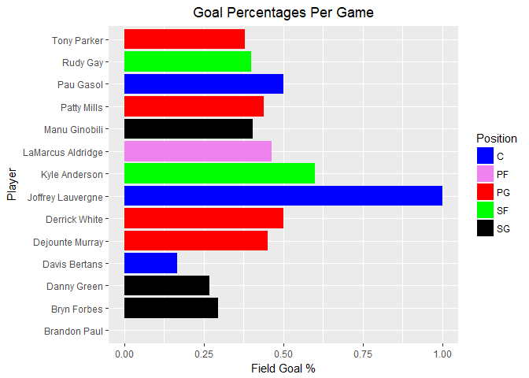

```r
Palette1 <- c('blue','violet','red','green','black')
ggplot( stats , aes( PLAYER, FG., fill=Position ) ) + geom_bar(stat="identity") + scale_fill_manual(values=Palette1) + labs(title="Goal Percentages Per Game",x ="Player", y = "Field Goal %" ) + coord_flip() + theme(plot.title = element_text(hjust = 0.5))
```